# CI Challenge 2021 - Q4

## California 2020 Census data profiling

Sudha Kumar 12/13/21

Source data: California 2020 Census - California_CA.csv file from https://www.kaggle.com/zusmani/us-census-2020/version/3?select=California_CA.csv  
File size: 721 MB  
669171 x 401 columns

### Install packages

```python
%pip install -U seaborn
```

```python
%pip install geopandas
```

```python
%pip install folium
```

### Import libraries

```python
import pandas as pd
import seaborn as sns
import matplotlib.pyplot as plt
import numpy as np
%matplotlib inline
import warnings
warnings.filterwarnings('ignore')
import databricks.koalas as ks
```

```python
from pyspark.sql.functions import regexp_replace, regexp_extract, col
```

### Read csv file with pandas

```python
df_pd = pd.read_csv("/dbfs/FileStore/tables/tables/skum_test/ca_2020_census/California_CA.csv", header='infer')
```

```python
df_pd.head()
```

|  | FILEID | STUSAB | SUMLEV | GEOVAR | GEOCOMP | CHARITER | CIFSN_x | LOGRECNO | GEOID | GEOCODE | REGION | DIVISION | STATE | STATENS | COUNTY | COUNTYCC | COUNTYNS | COUSUB | COUSUBCC | COUSUBNS | SUBMCD | SUBMCDCC | SUBMCDNS | ESTATE | ESTATECC | ESTATENS | CONCIT | CONCITCC | CONCITNS | … |
| --- | --- | --- | --- | --- | --- | --- | --- | --- | --- | --- | --- | --- | --- | --- | --- | --- | --- | --- | --- | --- | --- | --- | --- | --- | --- | --- | --- | --- | --- | --- |
| 0 | PLST | CA | 50 | 0 | 0 | 0 | 0 | 2 | 0500000US06001 | 6001 | 4 | 9 | 6 | 1779778 | 1.0 | H1 | 1675839.0 | NaN | NaN | NaN | NaN | NaN | NaN | NaN | NaN | NaN | NaN | NaN | NaN | … |
| 1 | PLST | CA | 50 | 0 | 0 | 0 | 0 | 3 | 0500000US06003 | 6003 | 4 | 9 | 6 | 1779778 | 3.0 | H1 | 1675840.0 | NaN | NaN | NaN | NaN | NaN | NaN | NaN | NaN | NaN | NaN | NaN | NaN | … |
| 2 | PLST | CA | 50 | 0 | 0 | 0 | 0 | 4 | 0500000US06005 | 6005 | 4 | 9 | 6 | 1779778 | 5.0 | H1 | 1675841.0 | NaN | NaN | NaN | NaN | NaN | NaN | NaN | NaN | NaN | NaN | NaN | NaN | … |
| 3 | PLST | CA | 50 | 0 | 0 | 0 | 0 | 5 | 0500000US06007 | 6007 | 4 | 9 | 6 | 1779778 | 7.0 | H1 | 1675842.0 | NaN | NaN | NaN | NaN | NaN | NaN | NaN | NaN | NaN | NaN | NaN | NaN | … |
| 4 | PLST | CA | 50 | 0 | 0 | 0 | 0 | 6 | 0500000US06009 | 6009 | 4 | 9 | 6 | 1779778 | 9.0 | H1 | 1675885.0 | NaN | NaN | NaN | NaN | NaN | NaN | NaN | NaN | NaN | NaN | NaN | NaN | … |

5 rows × 401 columns

### Read csv file with spark

```python
df_sp=spark.read.format("csv").option("header","true").load("/FileStore/tables/tables/skum_test/ca_2020_census/California_CA.csv")
```

```python
#df_sp.head()
```

```python
#df_sp.dtypes
```

### Read csv file with Spark using inferSchema option

```python
census_df_sp = spark.read.option("inferSchema", True).option("header", True).csv("/FileStore/tables/tables/skum_test/ca_2020_census/California_CA.csv")
```

```python
#display(census_df_sp)
```

```python
#display(census_df.summary())
```

```python
census_df_sp.count()
```

Out[11]: 669171

```python
len(census_df_sp.columns)
```

Out[12]: 401

### Convert Spark dataframe to Koalas dataframe to perform Pandas like operations

```python
import databricks.koalas as ks

census_ks = census_df_sp.to_koalas()
census_ks.head()
```

|  | FILEID | STUSAB | SUMLEV | GEOVAR | GEOCOMP | CHARITER | CIFSN_x6 | LOGRECNO | GEOID | GEOCODE | REGION | DIVISION | STATE | STATENS | COUNTY | COUNTYCC | COUNTYNS | COUSUB | COUSUBCC | COUSUBNS | SUBMCD | SUBMCDCC | SUBMCDNS | ESTATE | ESTATECC | ESTATENS | CONCIT | CONCITCC | CONCITNS | … |
| --- | --- | --- | --- | --- | --- | --- | --- | --- | --- | --- | --- | --- | --- | --- | --- | --- | --- | --- | --- | --- | --- | --- | --- | --- | --- | --- | --- | --- | --- | --- |
| 0 | PLST | CA | 50 | 00 | 0 | 0 | 0 | 2 | 0500000US06001 | 06001 | 4 | 9 | 6 | 1779778 | 1.0 | H1 | 1675839.0 | NaN | None | NaN | None | None | None | None | None | None | NaN | NaN | NaN | … |
| 1 | PLST | CA | 50 | 00 | 0 | 0 | 0 | 3 | 0500000US06003 | 06003 | 4 | 9 | 6 | 1779778 | 3.0 | H1 | 1675840.0 | NaN | None | NaN | None | None | None | None | None | None | NaN | NaN | NaN | … |
| 2 | PLST | CA | 50 | 00 | 0 | 0 | 0 | 4 | 0500000US06005 | 06005 | 4 | 9 | 6 | 1779778 | 5.0 | H1 | 1675841.0 | NaN | None | NaN | None | None | None | None | None | None | NaN | NaN | NaN | … |
| 3 | PLST | CA | 50 | 00 | 0 | 0 | 0 | 5 | 0500000US06007 | 06007 | 4 | 9 | 6 | 1779778 | 7.0 | H1 | 1675842.0 | NaN | None | NaN | None | None | None | None | None | None | NaN | NaN | NaN | … |
| 4 | PLST | CA | 50 | 00 | 0 | 0 | 0 | 6 | 0500000US06009 | 06009 | 4 | 9 | 6 | 1779778 | 9.0 | H1 | 1675885.0 | NaN | None | NaN | None | None | None | None | None | None | NaN | NaN | NaN | … |

### Read csv file with Koalas

Koalas is an open-source Python package that implements the pandas API on top of Apache Spark, to make the pandas API scalable to big data.

```python
import databricks.koalas as ks
data_ks = ks.read_csv("/FileStore/tables/tables/skum_test/ca_2020_census/California_CA.csv", header=0)
```

```python
#display(data_ks)
```

### Time to read 721 MB csv file during one of the runs

| Pandas | Spark | Spark with inferSchema option | Koalas |
| --- | --- | --- | --- |
| 24.44 secs | 7.14 secs | 5.44 secs | 3.22 secs |

```python
#data_ks.info()
```

```python
data_ks.shape
```

Out[17]: (669171, 401)

REGION Region  
DIVISION Division  
COUNTY County (FIPS)  
CBSA Metropolitan Statistical Area/Micropolitan Statistical Area  
MEMI Metropolitan/Micropolitan Indicator  
CSA Combined Statistical Area  
METDIV Metropolitan Division  
AREALAND Area (Land)  
AREAWATR Area (Water)  
BASENAME Area Base Name  
NAME Area Name-Legal/Statistical Area Description (LSAD) Term-Part Indicator  
FUNCSTAT Functional Status Code  
POP100 Population Count (100%)  
HU100 Housing Unit Count (100%)  
INTPTLAT Internal Point (Latitude)  
INTPTLON Internal Point (Longitude)  
LSADC Legal/Statistical Area Description Code  
P0010001 Total:  
P0010002 Population of one race:  
P0010003 White alone  
P0010004 Black or African American alone  
P0010005 American Indian and Alaska Native alone  
P0010006 Asian alone  
P0010007 Native Hawaiian and Other Pacific Islander alone  
P0010008 Some Other Race alone  
P0010009 Population of two or more races:  
P0010010 Population of two races:  
P0010011 White; Black or African American  
P0010012 White; American Indian and Alaska Native  
P0010013 White; Asian  
P0010014 White; Native Hawaiian and Other Pacific Islander  
P0010015 White; Some Other Race  
P0010016 Black or African American; American Indian and Alaska Native  
P0010017 Black or African American; Asian  
P0010018 Black or African American; Native Hawaiian and Other Pacific Islander  
P0010019 Black or African American; Some Other Race  
P0010020 American Indian and Alaska Native; Asian  
P0010021 American Indian and Alaska Native; Native Hawaiian and Other Pacific Islander  
P0010022 American Indian and Alaska Native; Some Other Race  
P0010023 Asian; Native Hawaiian and Other Pacific Islander  
P0010024 Asian; Some Other Race  
P0010025 Native Hawaiian and Other Pacific Islander; Some Other Race  
P0010026 Population of three races:  
P0010027 White; Black or African American; American Indian and Alaska Native  
P0010028 White; Black or African American; Asian  
P0010029 White; Black or African American; Native Hawaiian and Other Pacific Islander  
P0010030 White; Black or African American; Some Other Race  
P0010031 White; American Indian and Alaska Native; Asian  
P0010032 White; American Indian and Alaska Native; Native Hawaiian and Other Pacific Islander  
P0010033 White; American Indian and Alaska Native; Some Other Race  
P0010034 White; Asian; Native Hawaiian and Other Pacific Islander  
P0010035 White; Asian; Some Other Race  
P0010036 White; Native Hawaiian and Other Pacific Islander; Some Other Race  
P0010037 Black or African American; American Indian and Alaska Native; Asian  
P0010038 Black or African American; American Indian and Alaska Native; Native Hawaiian and Other Pacific Islander  
P0010039 Black or African American; American Indian and Alaska Native; Some Other Race  
P0010040 Black or African American; Asian; Native Hawaiian and Other Pacific Islander  
P0010041 Black or African American; Asian; Some Other Race  
P0010042 Black or African American; Native Hawaiian and Other Pacific Islander; Some Other Race  
P0010043 American Indian and Alaska Native; Asian; Native Hawaiian and Other Pacific Islander  
P0010044 American Indian and Alaska Native; Asian; Some Other Race  
P0010045 American Indian and Alaska Native; Native Hawaiian and Other Pacific Islander; Some Other Race  
P0010046 Asian; Native Hawaiian and Other Pacific Islander; Some Other Race  
P0010047 Population of four races:  
P0010048 White; Black or African American; American Indian and Alaska Native; Asian  
P0010049 White; Black or African American; American Indian and Alaska Native; Native Hawaiian and Other Pacific Islander  
P0010050 White; Black or African American; American Indian and Alaska Native; Some Other Race  
P0010051 White; Black or African American; Asian; Native Hawaiian and Other Pacific Islander  
P0010052 White; Black or African American; Asian; Some Other Race  
P0010053 White; Black or African American; Native Hawaiian and Other Pacific Islander; Some Other Race  
P0010054 White; American Indian and Alaska Native; Asian; Native Hawaiian and Other Pacific Islander  
P0010055 White; American Indian and Alaska Native; Asian; Some Other Race  
P0010056 White; American Indian and Alaska Native; Native Hawaiian and Other Pacific Islander; Some Other Race  
P0010057 White; Asian; Native Hawaiian and Other Pacific Islander; Some Other Race  
P0010058 Black or African American; American Indian and Alaska Native; Asian; Native Hawaiian and Other Pacific Islander  
P0010059 Black or African American; American Indian and Alaska Native; Asian; Some Other Race  
P0010060 Black or African American; American Indian and Alaska Native; Native Hawaiian and Other Pacific Islander; Some Other Race  
P0010061 Black or African American; Asian; Native Hawaiian and Other Pacific Islander; Some Other Race  
P0010062 American Indian and Alaska Native; Asian; Native Hawaiian and Other Pacific Islander; Some Other Race  
P0010063 Population of five races:  
P0010064 White; Black or African American; American Indian and Alaska Native; Asian; Native Hawaiian and Other Pacific Islander  
P0010065 White; Black or African American; American Indian and Alaska Native; Asian; Some Other Race  
P0010066 White; Black or African American; American Indian and Alaska Native; Native Hawaiian and Other Pacific Islander; Some Other Race  
P0010067 White; Black or African American; Asian; Native Hawaiian and Other Pacific Islander; Some Other Race  
P0010068 White; American Indian and Alaska Native; Asian; Native Hawaiian and Other Pacific Islander; Some Other Race  
P0010069 Black or African American; American Indian and Alaska Native; Asian; Native Hawaiian and Other Pacific Islander; Some Other Race  
P0010070 Population of six races:  
P0010071 White; Black or African American; American Indian and Alaska Native; Asian; Native Hawaiian and Other Pacific Islander; Some Other Race  
P0020002 Hispanic or Latino  
P0020003 Not Hispanic or Latino:  
H0010001 H1-1: Total  
H0010002 H1-2: Occupied  
H0010003 H1-3: Vacant  
P0050001 Total:  
P0050002 Institutionalized population:  
P0050003 Correctional facilities for adults  
P0050004 Juvenile facilities  
P0050005 Nursing facilities/Skilled-nursing facilities  
P0050006 Other institutional facilities  
P0050007 Noninstitutionalized population:  
P0050008 College/University student housing  
P0050009 Military quarters  
P0050010 Other noninstitutional facilities

### Subsetting from Spark dataframe

```python
census_df_sp_sub = census_df_sp.select(["REGION","DIVISION","COUNTY","CBSA","MEMI","CSA","METDIV","AREALAND","AREAWATR","BASENAME","Name","POP100","HU100","INTPTLAT","INTPTLON","LSADC","P0010001", "P0010002", "P0010003", "P0010004", "P0010005", "P0010006", "P0010007", "P0010008", "P0010009", "P0010010", "P0010011", "P0010012", "P0010013", "P0010014", "P0010015", "P0010016", "P0010017", "P0010018", "P0010019", "P0010020", "P0010021", "P0010022", "P0010023", "P0010024", "P0010025", "P0010026", "P0010027", "P0010028", "P0010029", "P0010030", "P0010031", "P0010032", "P0010033", "P0010034", "P0010035", "P0010036", "P0010037", "P0010038", "P0010039", "P0010040", "P0010041", "P0010042", "P0010043", "P0010044", "P0010045", "P0010046", "P0010047", "P0010048", "P0010049", "P0010050", "P0010051", "P0010052", "P0010053", "P0010054", "P0010055", "P0010056", "P0010057", "P0010058", "P0010059", "P0010060", "P0010061", "P0010062", "P0010063", "P0010064", "P0010065", "P0010066", "P0010067", "P0010068", "P0010069", "P0010070", "P0010071", "P0020002", "P0020003", "H0010001", "H0010002", "H0010003", "P0050001", "P0050002", "P0050003", "P0050004", "P0050005", "P0050006", "P0050007", "P0050008", "P0050009", "P0050010"])
#display(census_df_sp_sub)
```

```python
#df.colRegex("P001")
```

```python
display(census_df_sp_sub.summary())
```

| summary | REGION | DIVISION | COUNTY | CBSA | MEMI | CSA | METDIV | AREALAND | AREAWATR | BASENAME | Name | POP100 | HU100 | INTPTLAT | INTPTLON | LSADC | P0010001 | P0010002 | P0010003 | P0010004 | P0010005 | P0010006 | P0010007 | P0010008 | P0010009 | P0010010 | P0010011 | P0010012 | P0010013 | … |
| --- | --- | --- | --- | --- | --- | --- | --- | --- | --- | --- | --- | --- | --- | --- | --- | --- | --- | --- | --- | --- | --- | --- | --- | --- | --- | --- | --- | --- | --- | --- |
| count | 669171 | 669171 | 650290 | 650290 | 650290 | 650290 | 650290 | 669171 | 669171 | 669171 | 669171 | 669171 | 669171 | 669171 | 669171 | 669171 | 669171 | 669171 | 669171 | 669171 | 669171 | 669171 | 669171 | 669171 | 669171 | 669171 | 669171 | 669171 | 669171 | … |
| mean | 4.0 | 9.0 | 56.366931676636575 | 38679.26071752603 | 1.3898522197788679 | 554.2995555828937 | 76237.78717956605 | 2.8677515498694655E7 | 1445348.4535836133 | 1832.536732234136 | null | 3059.615147697674 | 1113.5215647420464 | 36.032115277906854 | -119.64066830452249 | 26.733684030450775 | 3059.615147697674 | 2613.714258388364 | 1258.4589409881778 | 173.5204469410659 | 48.9568824709977 | 472.2799613252816 | 12.19083612409982 | 648.3071905387412 | 445.9008893093096 | 416.4643730825155 | 19.981495013979984 | 29.66331176933848 | 48.420317078893135 | … |
| stddev | 0.0 | 0.0 | 28.31755854283744 | 15294.999450959238 | 1.623580576183806 | 270.1235591357882 | 33581.03897460754 | 7.881045914630078E8 | 4.494612437568705E7 | 1362.64644400938 | null | 66405.47319871612 | 24431.340821414025 | 2.3066087112499662 | 2.0902436730725986 | 25.362129522066663 | 66405.47319871612 | 56853.01741716403 | 26526.04242970642 | 4595.227009682515 | 1060.2947009505854 | 11095.468936577807 | 278.1856483724344 | 15286.754026573077 | 9606.180301680255 | 8971.494547229793 | 448.8439672083964 | 590.8450733585147 | 1074.9128948779255 | … |
| min | 4 | 9 | 1.0 | 12540.0 | 1.0 | 260.0 | 11244.0 | 0 | 0 | 0 | ABC Unified School District | 0 | 0 | 32.5395511 | -124.4136928 | 00 | 0 | 0 | 0 | 0 | 0 | 0 | 0 | 0 | 0 | 0 | 0 | 0 | 0 | … |
| 25% | 4 | 9 | 37.0 | 31080.0 | 1.0 | 348.0 | 36084.0 | 16661 | 0 | 1007.0 | null | 7 | 2 | 34.0052005 | -121.6376844 | 0.0 | 7 | 5 | 1 | 0 | 0 | 0 | 0 | 0 | 0 | 0 | 0 | 0 | 0 | … |
| 50% | 4 | 9 | 59.0 | 40140.0 | 1.0 | 472.0 | 99999.0 | 51601 | 0 | 2001.0 | null | 61 | 21 | 35.4357468 | -119.2696632 | 22.0 | 61 | 50 | 23 | 0 | 0 | 2 | 0 | 5 | 9 | 8 | 0 | 0 | 0 | … |
| 75% | 4 | 9 | 75.0 | 41860.0 | 1.0 | 999.0 | 99999.0 | 638110 | 0 | 3000.0 | null | 246 | 93 | 37.866253799999996 | -117.930457 | 57.0 | 246 | 213 | 105 | 10 | 4 | 29 | 1 | 48 | 36 | 34 | 2 | 3 | 4 | … |
| max | 4 | 9 | 115.0 | 99999.0 | 9.0 | 999.0 | 99999.0 | 282055294521 | 15719629492 | Zayante | Zayante CDP | 28573858 | 10571847 | 42.0074191 | -114.13926399999998 | OT | 28573858 | 24485003 | 11576460 | 1799185 | 447548 | 4474283 | 115115 | 6072412 | 4088855 | 3811637 | 194177 | 262089 | 459478 | … |

### Subsetting from Koalas dataframe

```python
data_ks_sub = data_ks[["REGION","DIVISION","COUNTY","CBSA","MEMI","CSA","METDIV","AREALAND","AREAWATR","BASENAME","NAME","POP100","HU100","INTPTLAT","INTPTLON","LSADC","P0010001", "P0010002", "P0010003", "P0010004", "P0010005", "P0010006", "P0010007", "P0010008", "P0010009", "P0010010", "P0010011", "P0010012", "P0010013", "P0010014", "P0010015", "P0010016", "P0010017", "P0010018", "P0010019", "P0010020", "P0010021", "P0010022", "P0010023", "P0010024", "P0010025", "P0010026", "P0010027", "P0010028", "P0010029", "P0010030", "P0010031", "P0010032", "P0010033", "P0010034", "P0010035", "P0010036", "P0010037", "P0010038", "P0010039", "P0010040", "P0010041", "P0010042", "P0010043", "P0010044", "P0010045", "P0010046", "P0010047", "P0010048", "P0010049", "P0010050", "P0010051", "P0010052", "P0010053", "P0010054", "P0010055", "P0010056", "P0010057", "P0010058", "P0010059", "P0010060", "P0010061", "P0010062", "P0010063", "P0010064", "P0010065", "P0010066", "P0010067", "P0010068", "P0010069", "P0010070", "P0010071", "P0020002", "P0020003", "H0010001", "H0010002", "H0010003", "P0050001", "P0050002", "P0050003", "P0050004", "P0050005", "P0050006", "P0050007", "P0050008", "P0050009", "P0050010"]]
```

#### Continuing with Koalas dataframe

```python
#data_ks_sub.dtypes
```

```python
data_ks_sub.head()
```

|  | REGION | DIVISION | COUNTY | CBSA | MEMI | CSA | METDIV | AREALAND | AREAWATR | BASENAME | NAME | POP100 | HU100 | INTPTLAT | INTPTLON | LSADC | P0010001 | P0010002 | P0010003 | P0010004 | P0010005 | P0010006 | P0010007 | P0010008 | P0010009 | P0010010 | P0010011 | P0010012 | P0010013 | … |
| --- | --- | --- | --- | --- | --- | --- | --- | --- | --- | --- | --- | --- | --- | --- | --- | --- | --- | --- | --- | --- | --- | --- | --- | --- | --- | --- | --- | --- | --- | --- |
| 0 | 4 | 9 | 1.0 | 41860.0 | 1.0 | 488.0 | 36084.0 | 1910017353 | 216902808 | Alameda | Alameda County | 1682353 | 621958 | 37.647139 | -121.912488 | 06 | 1682353 | 1491537 | 523836 | 164879 | 19659 | 545261 | 14123 | 223779 | 190816 | 171703 | 13579 | 10768 | 39888 | … |
| 1 | 4 | 9 | 3.0 | 99999.0 | 9.0 | 999.0 | 99999.0 | 1912292607 | 12557304 | Alpine | Alpine County | 1204 | 1540 | 38.621783 | -119.798352 | 06 | 1204 | 1085 | 814 | 10 | 236 | 12 | 0 | 13 | 119 | 89 | 5 | 10 | 6 | … |
| 2 | 4 | 9 | 5.0 | 99999.0 | 9.0 | 999.0 | 99999.0 | 1539965777 | 29438413 | Amador | Amador County | 40474 | 18805 | 38.443549 | -120.653858 | 06 | 40474 | 36596 | 31104 | 1236 | 757 | 582 | 82 | 2835 | 3878 | 3591 | 163 | 1123 | 307 | … |
| 3 | 4 | 9 | 7.0 | 17020.0 | 1.0 | 999.0 | 99999.0 | 4238488698 | 105260548 | Butte | Butte County | 211632 | 90133 | 39.665336 | -121.603209 | 06 | 211632 | 186947 | 149557 | 3644 | 4492 | 10533 | 573 | 18148 | 24685 | 22849 | 1764 | 6709 | 2396 | … |
| 4 | 4 | 9 | 9.0 | 99999.0 | 9.0 | 999.0 | 99999.0 | 2641837359 | 43789489 | Calaveras | Calaveras County | 45292 | 27422 | 38.191068 | -120.554106 | 06 | 45292 | 40264 | 36315 | 364 | 747 | 743 | 100 | 1995 | 5028 | 4706 | 195 | 1513 | 428 | … |

```python
data_ks_sub.describe()
```

|  | REGION | DIVISION | COUNTY | CBSA | MEMI | CSA | METDIV | AREALAND | AREAWATR | POP100 | HU100 | INTPTLAT | INTPTLON | P0010001 | P0010002 | P0010003 | P0010004 | P0010005 | P0010006 | P0010007 | P0010008 | P0010009 | P0010010 | P0010011 | P0010012 | P0010013 | P0010014 | P0010015 | P0010016 | … |
| --- | --- | --- | --- | --- | --- | --- | --- | --- | --- | --- | --- | --- | --- | --- | --- | --- | --- | --- | --- | --- | --- | --- | --- | --- | --- | --- | --- | --- | --- | --- |
| count | 669171.0 | 669171.0 | 650290.000000 | 650290.000000 | 650290.000000 | 650290.000000 | 650290.000000 | 6.691710e+05 | 6.691710e+05 | 6.691710e+05 | 6.691710e+05 | 669171.000000 | 669171.000000 | 6.691710e+05 | 6.691710e+05 | 6.691710e+05 | 6.691710e+05 | 669171.000000 | 6.691710e+05 | 669171.000000 | 6.691710e+05 | 6.691710e+05 | 6.691710e+05 | 669171.000000 | 669171.000000 | 669171.000000 | 669171.000000 | 6.691710e+05 | 669171.000000 | … |
| mean | 4.0 | 9.0 | 56.366932 | 38679.260718 | 1.389852 | 554.299556 | 76237.787180 | 2.867752e+07 | 1.445348e+06 | 3.059615e+03 | 1.113522e+03 | 36.032115 | -119.640668 | 3.059615e+03 | 2.613714e+03 | 1.258459e+03 | 1.735204e+02 | 48.956882 | 4.722800e+02 | 12.190836 | 6.483072e+02 | 4.459009e+02 | 4.164644e+02 | 19.981495 | 29.663312 | 48.420317 | 3.510182 | 2.807234e+02 | 2.895796 | … |
| std | 0.0 | 0.0 | 28.317559 | 15294.999451 | 1.623581 | 270.123559 | 33581.038975 | 7.881046e+08 | 4.494612e+07 | 6.640547e+04 | 2.443134e+04 | 2.306609 | 2.090244 | 6.640547e+04 | 5.685302e+04 | 2.652604e+04 | 4.595227e+03 | 1060.294701 | 1.109547e+04 | 278.185648 | 1.528675e+04 | 9.606180e+03 | 8.971495e+03 | 448.843967 | 590.845073 | 1074.912895 | 72.655065 | 6.136860e+03 | 71.657002 | … |
| min | 4.0 | 9.0 | 1.000000 | 12540.000000 | 1.000000 | 260.000000 | 11244.000000 | 0.000000e+00 | 0.000000e+00 | 0.000000e+00 | 0.000000e+00 | 32.539551 | -124.413693 | 0.000000e+00 | 0.000000e+00 | 0.000000e+00 | 0.000000e+00 | 0.000000 | 0.000000e+00 | 0.000000 | 0.000000e+00 | 0.000000e+00 | 0.000000e+00 | 0.000000 | 0.000000 | 0.000000 | 0.000000 | 0.000000e+00 | 0.000000 | … |
| 25% | 4.0 | 9.0 | 37.000000 | 31080.000000 | 1.000000 | 348.000000 | 36084.000000 | 1.665900e+04 | 0.000000e+00 | 7.000000e+00 | 2.000000e+00 | 34.005323 | -121.637698 | 7.000000e+00 | 5.000000e+00 | 1.000000e+00 | 0.000000e+00 | 0.000000 | 0.000000e+00 | 0.000000 | 0.000000e+00 | 0.000000e+00 | 0.000000e+00 | 0.000000 | 0.000000 | 0.000000 | 0.000000 | 0.000000e+00 | 0.000000 | … |
| 50% | 4.0 | 9.0 | 59.000000 | 40140.000000 | 1.000000 | 472.000000 | 99999.000000 | 5.159000e+04 | 0.000000e+00 | 6.100000e+01 | 2.100000e+01 | 35.434519 | -119.269756 | 6.100000e+01 | 5.000000e+01 | 2.300000e+01 | 0.000000e+00 | 0.000000 | 2.000000e+00 | 0.000000 | 5.000000e+00 | 9.000000e+00 | 8.000000e+00 | 0.000000 | 0.000000 | 0.000000 | 0.000000 | 4.000000e+00 | 0.000000 | … |
| 75% | 4.0 | 9.0 | 75.000000 | 41860.000000 | 1.000000 | 999.000000 | 99999.000000 | 6.380330e+05 | 0.000000e+00 | 2.460000e+02 | 9.300000e+01 | 37.866010 | -117.930126 | 2.460000e+02 | 2.130000e+02 | 1.050000e+02 | 1.000000e+01 | 4.000000 | 2.900000e+01 | 1.000000 | 4.800000e+01 | 3.600000e+01 | 3.400000e+01 | 2.000000 | 3.000000 | 4.000000 | 0.000000 | 2.400000e+01 | 0.000000 | … |
| max | 4.0 | 9.0 | 115.000000 | 99999.000000 | 9.000000 | 999.000000 | 99999.000000 | 2.820553e+11 | 1.571963e+10 | 2.857386e+07 | 1.057185e+07 | 42.007419 | -114.139264 | 2.857386e+07 | 2.448500e+07 | 1.157646e+07 | 1.799185e+06 | 447548.000000 | 4.474283e+06 | 115115.000000 | 6.072412e+06 | 4.088855e+06 | 3.811637e+06 | 194177.000000 | 262089.000000 | 459478.000000 | 31625.000000 | 2.532955e+06 | 29671.000000 | … |

Noticing the following issues from the 'describe' table: Some counties have 0 value for POP100 (population count 100%), HU100 (Housing count 100%), H0010001 (Total) ????

### Plot population be city / county / school district / census tract

```python
# Plot NAME vs POP100

plot_df = data_ks_sub[["NAME","POP100","INTPTLAT","INTPTLON"]]
plot_df.rename(columns={"POP100":"Total Population"}, inplace=True)
plot_df.head()
```

|  | NAME | Total Population | INTPTLAT | INTPTLON |
| --- | --- | --- | --- | --- |
| 0 | Alameda County | 1682353 | 37.647139 | -121.912488 |
| 1 | Alpine County | 1204 | 38.621783 | -119.798352 |
| 2 | Amador County | 40474 | 38.443549 | -120.653858 |
| 3 | Butte County | 211632 | 39.665336 | -121.603209 |
| 4 | Calaveras County | 45292 | 38.191068 | -120.554106 |

```python
plot_df.dtypes
```

Out[26]: NAME object Total Population int32 INTPTLAT float64 INTPTLON float64 dtype: object

```python
#plot_df["NAME"].value_counts()
```

The NAME column has County / City / Block / Census Tract / School District. Separating County data

```python
pd_temp = plot_df.toPandas()
pd_temp_city = pd_temp[pd_temp["NAME"].str.contains('city', regex=False)].drop_duplicates(subset=["NAME"])
pd_temp_county = pd_temp[pd_temp["NAME"].str.contains('County', regex=False)].drop_duplicates(subset=["NAME"])
pd_temp_school_district = pd_temp[pd_temp["NAME"].str.contains('School District', regex=False)].drop_duplicates(subset=["NAME"])
pd_temp_census_tract = pd_temp[pd_temp["NAME"].str.contains('Census Tract', regex=False)].drop_duplicates(subset=["NAME"])
pd_temp_block = pd_temp[pd_temp["NAME"].str.contains('Block', regex=False)].drop_duplicates(subset=["NAME"])
```

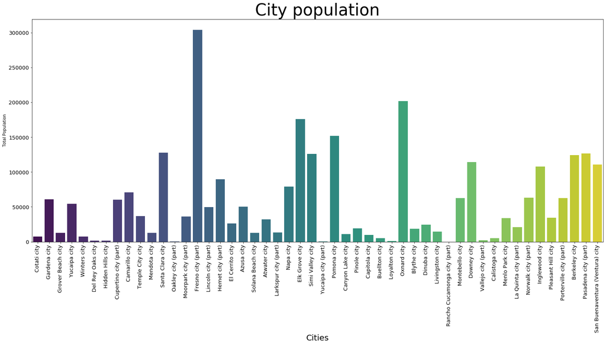

```python
plt.figure(figsize=(25,10))

splot = sns.barplot(x="NAME",y="Total Population", palette="viridis", data=pd_temp_city.sample(n=50, random_state=1))
splot.axes.set_title("City population",fontsize=40)
splot.set_xlabel("Cities",fontsize=20)
splot.tick_params(labelsize=13)

for item in splot.get_xticklabels():
    item.set_rotation(90)
```

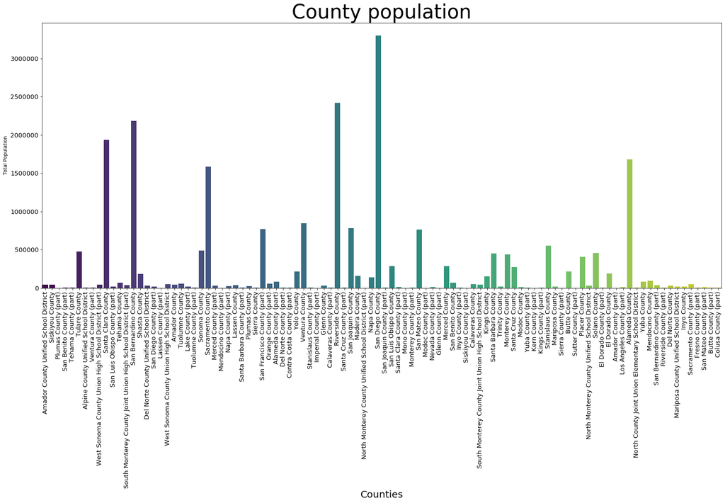

```python
plt.figure(figsize=(25,10))

splot = sns.barplot(x="NAME",y="Total Population", palette="viridis", data=pd_temp_county.sample(n=100, random_state=1))
splot.axes.set_title("County population",fontsize=40)
splot.set_xlabel("Counties",fontsize=20)
splot.tick_params(labelsize=13)

for item in splot.get_xticklabels():
    item.set_rotation(90)
```

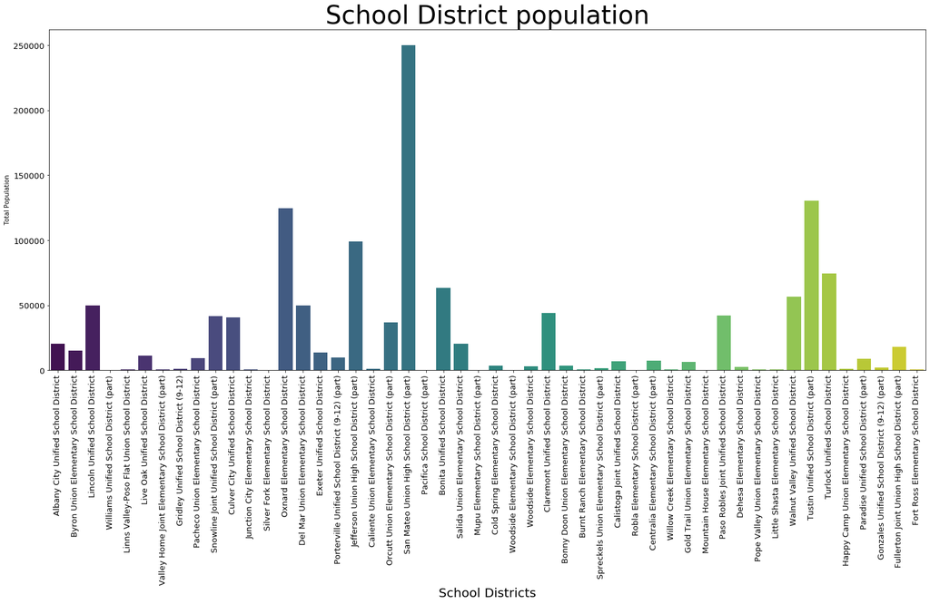

```python
plt.figure(figsize=(25,10))

splot = sns.barplot(x="NAME",y="Total Population", palette="viridis", data=pd_temp_school_district.sample(n=50, random_state=1))
splot.axes.set_title("School District population",fontsize=40)
splot.set_xlabel("School Districts",fontsize=20)
splot.tick_params(labelsize=13)

for item in splot.get_xticklabels():
    item.set_rotation(90)
```

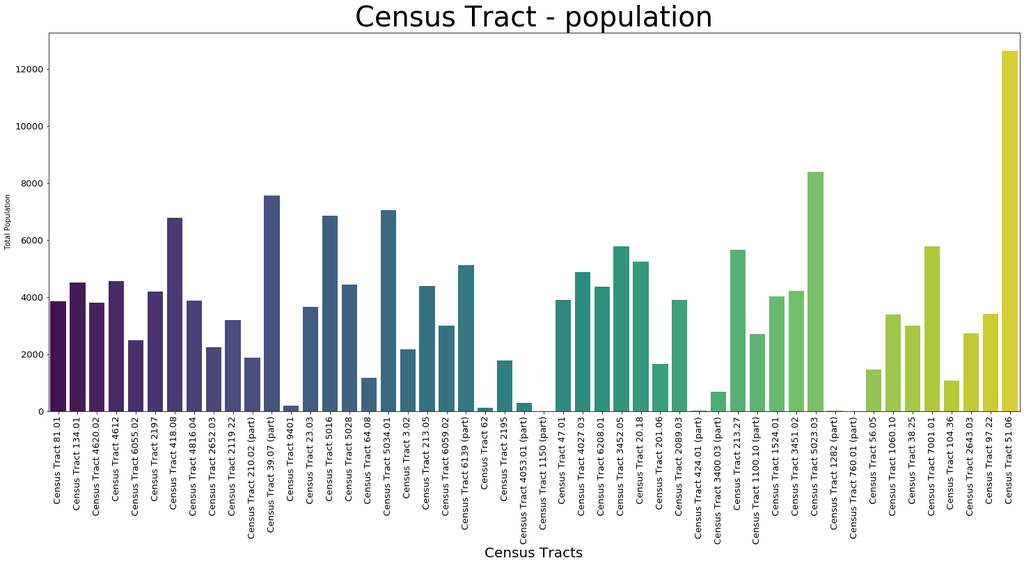

```python
plt.figure(figsize=(25,10))

splot = sns.barplot(x="NAME",y="Total Population", palette="viridis", data=pd_temp_census_tract.sample(n=50, random_state=1))
splot.axes.set_title("Census Tract - population",fontsize=40)
splot.set_xlabel("Census Tracts",fontsize=20)
splot.tick_params(labelsize=13)

for item in splot.get_xticklabels():
    item.set_rotation(90)
```

### Plot population distribution by ethnicity in San Diego County

```python
# For a NAME, check the distribution of population by one race
# P0010001 Total:
# P0010002 Population of one race:
# P0010003 White alone
# P0010004 Black or African American alone
# P0010005 American Indian and Alaska Native alone
# P0010006 Asian alone
# P0010007 Native Hawaiian and Other Pacific Islander alone
# P0010008 Some Other Race alone
# P0020002 Hispanic or Latino

plot_df2 = data_ks_sub[["NAME","P0010003","P0010004","P0010005","P0010006","P0010007","P0010008","P0020002"]]
plot_df2.rename(columns={"P0010003":"White","P0010004":"Black or African American","P0010005":"American Indian and Alaska Native","P0010006":"Asian","P0010007":"Native Hawaiian and Other Pacific Islander","P0010008":"Some Other Race","P0020002":"Hispanic or Latino"}, inplace=True)
plot_df2.head()
```

|  | NAME | White | Black or African American | American Indian and Alaska Native | Asian | Native Hawaiian and Other Pacific Islander | Some Other Race | Hispanic or Latino |
| --- | --- | --- | --- | --- | --- | --- | --- | --- |
| 0 | Alameda County | 523836 | 164879 | 19659 | 545261 | 14123 | 223779 | 393749 |
| 1 | Alpine County | 814 | 10 | 236 | 12 | 0 | 13 | 84 |
| 2 | Amador County | 31104 | 1236 | 757 | 582 | 82 | 2835 | 6014 |
| 3 | Butte County | 149557 | 3644 | 4492 | 10533 | 573 | 18148 | 40112 |
| 4 | Calaveras County | 36315 | 364 | 747 | 743 | 100 | 1995 | 5865 |

```python
pd_temp2 = plot_df2.toPandas()
pd_temp_SD = pd_temp2[pd_temp2["NAME"] == 'San Diego County']
pd_temp_SD
```

|  | NAME | White | Black or African American | American Indian and Alaska Native | Asian | Native Hawaiian and Other Pacific Islander | Some Other Race | Hispanic or Latino |
| --- | --- | --- | --- | --- | --- | --- | --- | --- |
| 36 | San Diego County | 1633129 | 155813 | 40968 | 410752 | 15286 | 520994 | 1119629 |

```python
pd_temp_SD = pd_temp_SD.reset_index(drop=True)
pd_temp_SD
```

|  | NAME | White | Black or African American | American Indian and Alaska Native | Asian | Native Hawaiian and Other Pacific Islander | Some Other Race | Hispanic or Latino |
| --- | --- | --- | --- | --- | --- | --- | --- | --- |
| 0 | San Diego County | 1633129 | 155813 | 40968 | 410752 | 15286 | 520994 | 1119629 |

```python
pd_temp_SD = pd_temp_SD.drop(["NAME"], axis=1)
pd_temp_SD
```

|  | White | Black or African American | American Indian and Alaska Native | Asian | Native Hawaiian and Other Pacific Islander | Some Other Race | Hispanic or Latino |
| --- | --- | --- | --- | --- | --- | --- | --- |
| 0 | 1633129 | 155813 | 40968 | 410752 | 15286 | 520994 | 1119629 |

```python
pd_temp_SD_T = pd_temp_SD.T
#pd_temp_SD_T = pd_temp_SD_T.rename(columns={"Population"})
pd_temp_SD_T
```

|  | 0 |
| --- | --- |
| White | 1633129 |
| Black or African American | 155813 |
| American Indian and Alaska Native | 40968 |
| Asian | 410752 |
| Native Hawaiian and Other Pacific Islander | 15286 |
| Some Other Race | 520994 |
| Hispanic or Latino | 1119629 |

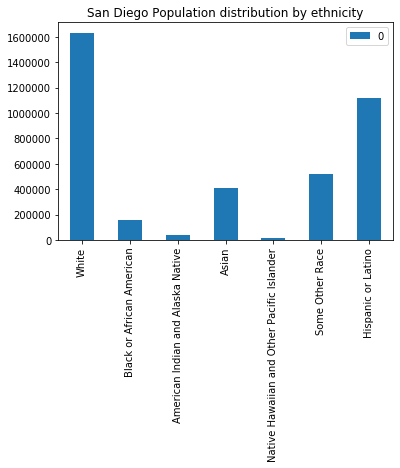

```python
plt.figure(figsize=(35,10))
ax = pd_temp_SD_T.plot.bar()
plt.title("San Diego Population distribution by ethnicity")
```

### Use Geopandas to show population bubbles on a Map

```python
pd_temp_city.head()
```

|  | NAME | Total Population | INTPTLAT | INTPTLON |
| --- | --- | --- | --- | --- |
| 36816 | Adelanto city | 38046 | 34.580902 | -117.439458 |
| 36818 | Agoura Hills city | 20299 | 34.148942 | -118.763930 |
| 36823 | Alameda city | 78280 | 37.741911 | -122.259914 |
| 36825 | Albany city | 20271 | 37.890650 | -122.318116 |
| 36828 | Alhambra city | 82868 | 34.083571 | -118.136444 |

```python
pd_temp_city.shape
```

Out[40]: (675, 4)

```python
pd_temp_city_summary = pd_temp_city.describe()
pd_temp_city_summary
```

|  | Total Population | INTPTLAT | INTPTLON |
| --- | --- | --- | --- |
| count | 6.750000e+02 | 675.000000 | 675.000000 |
| mean | 6.075501e+04 | 35.913016 | -119.678155 |
| std | 1.791500e+05 | 2.252842 | 2.139734 |
| min | 0.000000e+00 | 32.569140 | -124.261239 |
| 25% | 7.344000e+03 | 33.930746 | -121.826875 |
| 50% | 2.703800e+04 | 35.194361 | -119.318750 |
| 75% | 6.898100e+04 | 37.830509 | -117.869322 |
| max | 3.898747e+06 | 41.964965 | -114.593545 |

```python
pd_temp_city_summary.shape
```

Out[42]: (8, 3)

```python
max_pop_val = pd_temp_city_summary["Total Population"]["max"]
max_pop_val
```

Out[43]: 3898747.0

```python
pd_temp_city["Circle_radius"] = pd_temp_city["Total Population"].apply(lambda x: x / max_pop_val)
pd_temp_city.head()
```

|  | NAME | Total Population | INTPTLAT | INTPTLON | Circle_radius |
| --- | --- | --- | --- | --- | --- |
| 36816 | Adelanto city | 38046 | 34.580902 | -117.439458 | 0.009759 |
| 36818 | Agoura Hills city | 20299 | 34.148942 | -118.763930 | 0.005207 |
| 36823 | Alameda city | 78280 | 37.741911 | -122.259914 | 0.020078 |
| 36825 | Albany city | 20271 | 37.890650 | -122.318116 | 0.005199 |
| 36828 | Alhambra city | 82868 | 34.083571 | -118.136444 | 0.021255 |

```python
pd_temp_city = pd_temp_city.drop_duplicates(subset=["NAME"])
pd_temp_city.shape
```

Out[45]: (675, 5)

```python
pd_temp_city["Total Population"].describe()
```

Out[46]: count 6.750000e+02 mean 6.075501e+04 std 1.791500e+05 min 0.000000e+00 25% 7.344000e+03 50% 2.703800e+04 75% 6.898100e+04 max 3.898747e+06 Name: Total Population, dtype: float64

```python
pd_temp_city[pd_temp_city["NAME"] == 'Santa Barbara city']
```

|  | NAME | Total Population | INTPTLAT | INTPTLON | Circle_radius |
| --- | --- | --- | --- | --- | --- |
| 38103 | Santa Barbara city | 88665 | 34.400601 | -119.712954 | 0.022742 |

```python
#import folium as f

# Make an empty map
#mp = f.Map(location=[37,-119], tiles="OpenStreetMap", zoom_start=6)
#mp = f.Map(location=[37,-119], control_scale=True, zoom_start=6)
#mp
```

```python
import folium as f

# Make an empty map
mp = f.Map(location=[37,-119], control_scale=True, zoom_start=7)

#data_m=pd_temp_city.sample(n=500, random_state=1)
data_m=pd_temp_city
for i in range(0,data_m.shape[0]):
  popup = """
  #City Name : <b>%s</b><br>
  #Population : <b>%s</b><br>
  """ % (data_m.iloc[i]["NAME"],
         data_m.iloc[i]["Total Population"])
  f.Circle(
      location=[data_m.iloc[i]['INTPTLAT'], data_m.iloc[i]['INTPTLON']],
      tooltip=popup,
      #popup=data_m.iloc[i]['NAME'],
      radius=float(data_m.iloc[i]['Circle_radius'])*50000,
      color='blue',
      fill=True,
      #fill_color='blue'
   ).add_to(mp)
mp

#import webbrowser
#map_osm = folium.Map(location=[45.5236, -122.6750])
#mp.save('map.html')
#webbrowser.open('map.html')

#html_map = mp._repr_html_()
#displayHTML(html_map)

from IPython.core.display import HTML

HTML(mp._repr_html_())
```

Make this Notebook Trusted to load map: File -> Trust Notebook

[interactive chart not shown]

```python
#mp.save("/FileStore/sukumar/Ca_census_map.html")

#dbutils.fs.put("/FileStore/sukumar/Ca_census_map.html", mp)
```

### Institutionalized and non institutionalized population

```python
#P0050002 Institutionalized population:
#P0050003 Correctional facilities for adults
#P0050004 Juvenile facilities
#P0050005 Nursing facilities/Skilled-nursing facilities
#P0050006 Other institutional facilities
#P0050007 Noninstitutionalized population:
```

```python
df_k_means = data_ks_sub[["NAME","P0050002","P0050003","P0050004","P0050005","P0050006","P0050007"]].toPandas()
df_k_means.rename(columns={"P0050002":"Institutionalized population","P0050003":"Correctional facilities for adults","P0050004":"Juvenile facilities","P0050005":"Nursing facilities/Skilled-nursing facilities","P0050006":"Other institutional facilities","P0050007":"Noninstitutionalized population"}, inplace=True)
df_k_means = df_k_means[df_k_means["NAME"].str.contains('city', regex=False)].drop_duplicates(subset=["NAME"])
df_k_means.head()
```

|  | NAME | Institutionalized population | Correctional facilities for adults | Juvenile facilities | Nursing facilities/Skilled-nursing facilities | Other institutional facilities | Noninstitutionalized population |
| --- | --- | --- | --- | --- | --- | --- | --- |
| 36816 | Adelanto city | 2674 | 2674 | 0 | 0 | 0 | 77 |
| 36818 | Agoura Hills city | 148 | 0 | 0 | 148 | 0 | 0 |
| 36823 | Alameda city | 916 | 0 | 0 | 916 | 0 | 614 |
| 36825 | Albany city | 10 | 0 | 0 | 10 | 0 | 1385 |
| 36828 | Alhambra city | 691 | 21 | 37 | 547 | 86 | 212 |

```python
df_k_means.shape
```

Out[52]: (675, 7)

```python
df_k_means.dtypes
```

Out[53]: NAME object Institutionalized population int32 Correctional facilities for adults int32 Juvenile facilities int32 Nursing facilities/Skilled-nursing facilities int32 Other institutional facilities int32 Noninstitutionalized population int32 dtype: object

```python
df_k_means["Nursing facilities/Skilled-nursing facilities"].describe()
```

Out[54]: count 675.000000 mean 206.779259 std 657.850524 min 0.000000 25% 0.000000 50% 60.000000 75% 229.000000 max 14609.000000 Name: Nursing facilities/Skilled-nursing facilities, dtype: float64

```python
df_k_means_sub = df_k_means[(df_k_means["Nursing facilities/Skilled-nursing facilities"] < 1000) & (df_k_means["Nursing facilities/Skilled-nursing facilities"] > 0)]
```

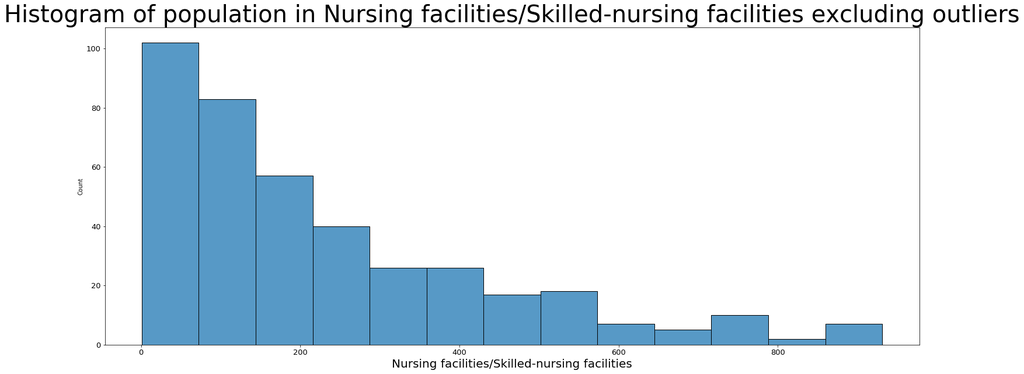

```python
plt.figure(figsize=(25,10))

splot = sns.histplot(data = df_k_means_sub, x="Nursing facilities/Skilled-nursing facilities",palette="viridis")
splot.axes.set_title("Histogram of population in Nursing facilities/Skilled-nursing facilities excluding outliers",fontsize=40)
splot.set_xlabel("Nursing facilities/Skilled-nursing facilities",fontsize=20)
splot.tick_params(labelsize=13)
```

### K Means clustering of institutionalized and non institutionalized population

```python
X_df = df_k_means_sub[["Institutionalized population","Noninstitutionalized population"]]
X_df = X_df.dropna()
X_df.shape
```

Out[57]: (400, 2)

```python
X = X_df.values
```

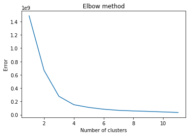

```python
from sklearn.cluster import KMeans

Error = []
for i in range(1, 12):
  kmeans = KMeans(n_clusters = i)
  kmeans.fit(X)
  Error.append(kmeans.inertia_)

plt.plot(range(1,12), Error)
plt.title("Elbow method")
plt.xlabel("Number of clusters")
plt.ylabel("Error")
```

Based on Elbow method, choosing n_clusters = 4

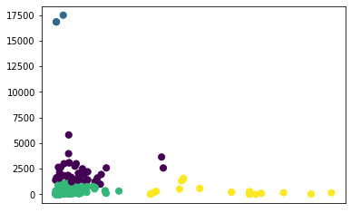

```python
from sklearn.cluster import KMeans

Kmean = KMeans(n_clusters=4)
y = Kmean.fit_predict(X)

plt.figsize=(25,10)
frame = plt.scatter(X[:,0], X[:,1], c=y, s=50, cmap='viridis')
frame.axes.get_xaxis().set_visible(False)
```